# Chapter 8: Hypothesis Testing for Population Proportions

COR 142 C

Author

Dr. Kao

## Section 8.1. Introduction to Hypothesis Testing

**TipThe ✋ Game**

**The Rule**

**Question 1**

If the coin is tossed 10 times, how often do you expect to be slapped?

**Question 3**

How would you go about proving your claim?

**Disclaimer:** No actual slapping will occur in COR 142 C. This is a hypothetical game for educational purposes only.

**TipAre You Full of 💩?**

The person sits next to you in COR 142 C claims that they are *basically an influencer* at Flagler because their TikTok videos was getting way more likes than the average user.

Naturally, you are pretty skeptical of your neighbor’s claim. How would you go about calling them out on their 💩?

We all like to prove people wrong, right? But how do we do that in a systematically to make sure that we are using data and logic rather than just our gut feelings? This is where *hypothesis testing* comes in!

In its broadest sense, **hypothesis testing** is a method of making decisions (like deciding whether the coin rigged and your neighbor full of 💩) using data. These decisions are made by comparing what we actually observe with what we would expect to find if a specific *hypothesis* (a fancy word for assumption) were true.

When you hear people use the catch phrase *data-driven decision-making*, they are often referring to hypothesis testing.

In every hypothesis test, we have two competing scenarios: A scenario where how things should be in a normal, ideal world where everything is fair, and second scenario where things are different from the ideal world. The normal, ideal world scenario is called the **null hypothesis** (denoted by the symbol $H_0$), while the alternative scenario is called the **alternative hypothesis** (denoted by the symbol $H_a$).

**TipThe ✋ Game, Revisited**

In the ✋ game, we suspected that the coin is an unfair one. In an normal, ideal world, we expect the proportion of a coin landing on tails to be $0.5$. An unfair coin would have a proportion of tails different from $0.5$.

We can symbolically represent our two competing scenarios as follows: Let $p$ be the proportion of tails when the coin is tossed.

- Null hypothesis: $H_0: p = 0.5$
- Alternative hypothesis: $H_a: p \ne 0.5$

Let’s take a moment to look at the alternative hypothesis. Saying that $p \ne 0.5$ means that the proportion of tails is *not* $0.5$. This means that $p$ is either greater than $0.5$ ($p > 0.5$), or $p$ is less than $0.5$ ($p < 0.5$).

$p \ne 0.5$ doesn’t quite fit the scenario from the ✋ game, because no one would forget being slapped in the face 9 consecutive times. In this case, our suspicion is that the coin lands on tails *more often* than expected.

So, the appropriate alternative hypothesis should be $p > 0.5$.

Let’s reframe the alternative hypothesis to better reflect the scenario from the ✋ game:

- $H_0: p = 0.5$
- $H_a: p > 0.5$

**TipExample 8.1.1.**

**Question**

Suppose the proportion of all Flagler students who eat at DHall at least once a day was 60% last school year. The DHall service provider, Aramark, wants to know whether this proportion has changed this year. Help the manager formulate the null and alternative hypotheses for hypothesis testing.

**Answer**

The proportion from last year is $p = 0.6$, which serves as the null hypothesis. The question we want to answer is whether this proportion has *changed*. In other words, $p \ne 0.6$. Therefore, the hypotheses are:

- $H_0: p = 0.6$
- $H_a: p \ne 0.6$

**TipExample 8.1.2.**

**Question.**

According to a 2015 survey by the University of Michigan, 71.5% of high school seniors in the U.S. had a driver’s license. A sociologist believes that this rate has declined. A sample of 500 randomly selected high school seniors finds that 350 of them had a driver’s license.

What are the null and alternative hypotheses for testing the sociologist’s claim?

**Answer.**

The proportion from the 2015 survey is $p = 0.715$, which serves as the null hypothesis. The sociologist believes that this rate has *declined*, which means that $p < 0.715$. Therefore, the hypotheses are:

- $H_0: p = 0.715$
- $H_a: p < 0.715$

From the above few examples, we can see that the null hypothesis is always an *equality statement* (e.g., $p = 0.5$, $p = 0.6$, $p = 0.715$), while the alternative hypothesis is always an *inequality statement* (e.g., $p \ne 0.5$, $p > 0.5$, $p < 0.715$).

**Important**

- The null hypothesis *always* contains an equality sign (“$=$”).
- An alternative hypothesis with a “$<$” or “$>$” is called a **one-sided hypothesis** or **one-tailed hypothesis**.
- An alternative hypothesis with a “$\ne$” is called a **two-sided hypothesis** or **two-tailed hypothesis**.
- We use $p_0$ to denote the hypothesized population proportion under the null hypothesis.

|  | Two-Sided | One-Sided (Left) | One-Sided (Right) |
| --- | --- | --- | --- |
| Null Hypothesis | $H_0: p = p_0$ | $H_0: p = p_0$ | $H_0: p = p_0$ |
| Alternative Hypothesis | $H_a: p \ne p_0$ | $H_a: p < p_0$ | $H_a: p > p_0$ |

## Section 8.2. The Machinery of Hypothesis Testing

### 8.2.1. The Three Steps of Hypothesis Testing

The major steps of a hypothesis test can be visualized in the following flowchart:

```
---
config:
  look: handDrawn
  theme: neutral
---

flowchart TD

A(Formulate Hypotheses) --> B(Calculate Test Statistic and p-Value) --> C(Decision Rule)

style A color:#000000
style B color:#000000
style C color:#000000
```

Since we have already covered the first step of formulating hypotheses, let’s move on to the second step of calculating the test statistic and $p$-value.

### 8.2.2. Calculating the Test Statistic

In the ✋ game, you suspected that the coin is unfair because tails came up 9 out of 10 times. And your instinct is telling you that this result is very unlikely to happen if the coin is actually fair.

In a hypothesis test, we want to know how likely the observed data are to occur *if* the null hypothesis is true. This is the core idea behind how hypothesis testing works.

During this stage of the hypothesis testing, we do the following:

1. Check the conditions for the central limit theorem.
- Sample is random and independent.
- Sample size is sufficiently large: $np_0 \geqslant 10$ and $n(1 - p_0) \geqslant 10$.
- Sufficient population size: $N \geqslant 10n$.
2. Compute two important quantities: the **test statistic** and the **$p$-value**. These two quantity let us know how compatible the observed data is with the null hypothesis $H_0$.

Plainly speaking, a **test statistic** is a number that tells us how far our sample result is from what we would expect to see if the null hypothesis were true. To make the process consistent across different types of hypothesis tests, we standardize the test statistic by finding how many standard deviations the sample result is away from the hypothesized population parameter under the null hypothesis.

This standardization gives all test statistics the same general form:
$$\text{Test Statistic} = \frac{\text{Estimator} - \text{Null Value}}{\text{SE}}$$

**NoteTest Statistic for One-Proportion $z$-Test**

If the conditions for the central limit theorem are satisfied with a null hypothesis $H_0: p = p_0$ and sample proportion $\hat{p}$, then the test statistic for a one-proportion $z$-test is given by
$$z = \frac{\hat{p} - p_0}{\text{SE}}, \quad \text{where} \quad \text{SE} = \sqrt{\frac{p_0(1 - p_0)}{n}}.$$

The test statistic for a one-proportion $z$-test is often referred to as the **$z$-statistic**.

**Important**

If the null hypothesis is true, then the $z$-statistic will be close to zero. The farther the test statistic is away from zero, the more evidence we have against the null hypothesis $H_0$.

**NoteVisualizing the Test Statistic and the $p$-Value.**

The reason why we standardize the test statistic is that it allows us to use the standard normal distribution (the $z$-distribution) to quantify how likely the observed data are to occur if the null hypothesis were true. This quantification is done through the **$p$-value**, which is the probability of observing a test statistic as extreme as, or more extreme than, the one calculated from the sample data, assuming that the null hypothesis is true. In each plot, the *shaded region(s) represent the $p$-value for the corresponding alternative hypothesis.*

**\(H_a: p \ne p_0\)**

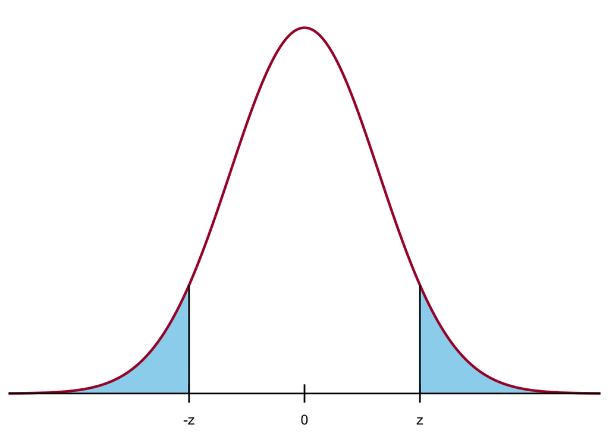

**\(H_a: p < p_0\)**

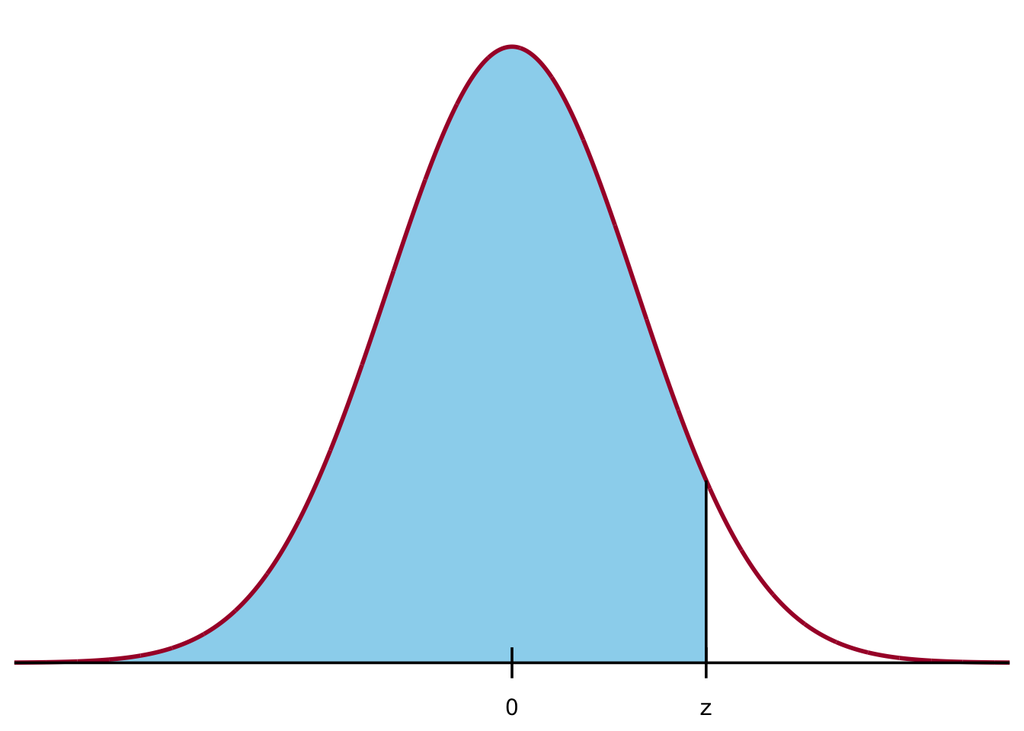

**\(H_a: p > p_0\)**

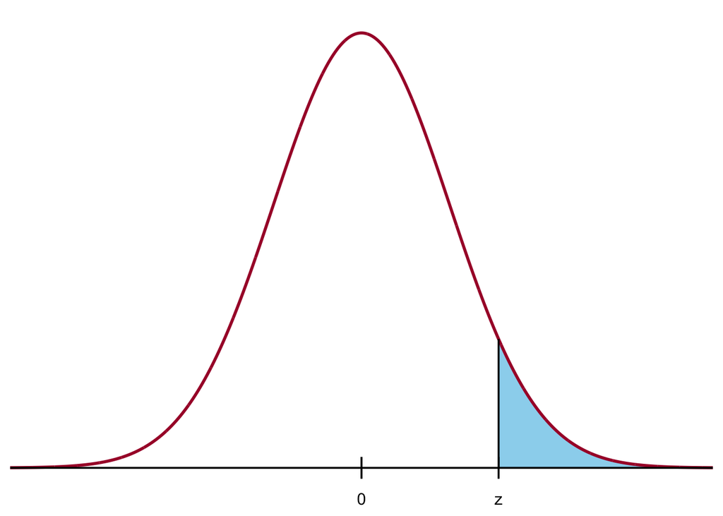

The $p$-value is typically calculated using a calculator or a computer. You will not be asked to calculate any $p$-value by hand in this course. This [webapp](https://ckaoxvii.github.io/population-proportion-hypothesis-test/) calculates the $p$-values for you.

### 8.2.3. Errors in Hypothesis Testing

Hypothesis testing in statistics can be compared to a criminal trial in the U.S. legal system (in a very simplistic way). In a criminal trial, the jury must consider two possible claims:

- The defendant is innocent. ($H_0$)
- The defendant is guilty. ($H_a$)

Since the U.S. legal system holds the principle of “presumed innocence”, a defendent is innocent until proven guilty. Moreover, the jury should only bring a guilty verdict if there is *sufficient evidence* to prove that the defendent is *guilty beyond a reasonable doubt*. The task of providing sufficient evidence to prove the defendent’s guilt lies with the prosecution.

In hypothesis testing, the person conducting the test has the role that is similar to the prosecutor in a criminal trial. They must provide sufficient evidence to reject the null hypothesis $H_0$ in favor of the alternative hypothesis $H_a$. If there is insufficient evidence, we fail to reject $H_0$.

**Important**

One important thing worth emphasizing here is that *failing to reject* $H_0$ does not mean that we have proven $H_0$ to be true. It simply means that we do not have sufficient evidence to conclude that $H_a$ is true. Just like in a criminal trial, a not guilty verdict does not mean that the defendant is innocent. It simply means that there is insufficient evidence to conclude that the defendant is guilty.

This criminal trial analogy also extends to another aspect of the hypothesis testing: The types of errors that can be made in hypothesis testing. There are two types of errors that can be made in hypothesis testing:

**NoteTypes of Errors in Hypothesis Testing**

1. **Type I Error**: Rejecting the null hypothesis $H_0$ when it is actually true. This is similar to convicting an innocent defendant. Type I error is also called a **false positive**.
2. **Type II Error**: Failing to reject the null hypothesis $H_0$ when it is actually false. This is similar to acquitting a guilty defendant. Type II error is also called a **false negative**.

|  | Reject $H_0$ | Fail to Reject $H_0$ |
| --- | --- | --- |
| $H_0$ True | Bad, Type I Error Significance Level: $\alpha$ | Good |
| $H_0$ False | Good | Bad, Type II Error |

**NoteThe Significance Level: $\alpha$**

In practice, we want to minimize the probability of making a Type I error. (Convicting an innocent person is considered a graver mistake than letting a guilty person go free.)

To control the probability of making a Type I error, we set a threshold called the **significance level**, and we denote this by the Greek letter $\alpha$ (alpha). The significance level $\alpha$ is the maximum acceptable probability of making a Type I error.

Common choices for the significance level $\alpha$ are $0.05$ (5%), $0.01$ (1%), and $0.10$ (10%). In most social science research, $\alpha = 0.05$ is the standard choice. In this course, unless otherwise specified, we will use $\alpha = 0.05$ as the significance level for hypothesis testing.

### 8.2.4. Decision Rule in Hypothesis Testing

**NoteDecision Rule in Hypothesis Testing**

The decision of whether to reject or fail to reject the null hypothesis $H_0$ is based on the evidence provided by the data. In the next section we will talk about how to quantify the evidence against the null hypothesis using the test statistic and the $p$-value. For now, we can summarize the decision rule in hypothesis testing as follows:

- If $p$-value $\leqslant \alpha$, we reject the null hypothesis $H_0$. This means that the evidence against $H_0$ is strong enough to conclude that $H_a$ is true.
- If $p$-value $> \alpha$, we fail to reject the null hypothesis $H_0$. This means that the evidence against $H_0$ is not strong enough to conclude that $H_a$ is true.

### 8.2.5. Examples

**TipThe ✋ Game, One Last Time**

**Question**

Recall that in the ✋ game, you suspected that the coin is unfair because tails came up 9 out of 10 times. Complete the hypothesis test for this scenario by completing the following steps.

1. Restate the null and alternative hypotheses. What are the values of $p_0$, $n$, and $\hat{p}$?
2. Assuming that the conditions for the Central Limit Theorem holds. Calculate the standard error and the $z$-statistic by hand. Then us the [webapp](https://ckaoxvii.github.io/population-proportion-hypothesis-test/) to find the $p$-value.
3. Using a significance level of $\alpha = 0.05$, what is your conclusion regarding the fairness of the coin?

**Answer**

1. $p_0$ is the null/hypothesized proportion, i.e., the proportion of a coin landing on tails if the coin is fair. Therefore, $p_0 = 0.5$. The sample size is $n = 10$, and the sample proportion is $\hat{p} = \frac{9}{10} = 0.9$. The hypotheses are:
- $H_0: p = 0.5$
- $H_a: p > 0.5$
2. The standard error is calculated as follows:
   $$\text{SE} = \sqrt{\frac{p_0(1 - p_0)}{n}} = \sqrt{\frac{0.5(1 - 0.5)}{10}} = \sqrt{\frac{0.25}{10}} = \sqrt{0.025} \approx 0.1581.$$
   The $z$-statistic is calculated as follows:
   $$z = \frac{\hat{p} - p_0}{\text{SE}} = \frac{0.9 - 0.5}{0.1581} \approx \frac{0.4}{0.1581} \approx 2.53.$$
   The $p$-value can be found using the [webapp](https://ckaoxvii.github.io/population-proportion-hypothesis-test/). Inputting $p_0 = 0.5$, $n = 10$, and $\hat{p} = 0.9$ into the webapp gives a $p$-value of approximately $0.0057$.
3. With a significance level of $\alpha = 0.05$, we see that
   $$\text{$p$-value} 0.0057 < 0.05 = \alpha.$$
   Therefore, we reject the null hypothesis $H_0$ and conclude that there is sufficient evidence to suggest that the coin is unfair.

**TipExample 8.2.1.**

**Question**

In 2015, the Gallup Poll reported that 55% of Americans stated that they believed that global warming is caused by human activities. In 2017, 63% of those responding to a Gallup Poll believed that global warming is caused by human activities. Assume that the sample size for the 2017 poll was 1000. Can we conclude that the percentage of all Americans who believe that global warming is caused by human activities did indeed increase from 2015 to 2017?

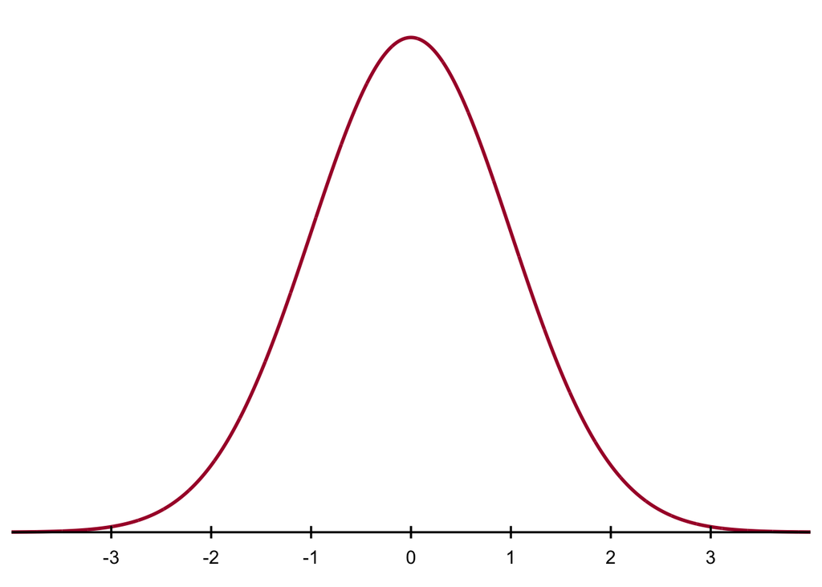

**Answer**

1. $p_0 = 0.55$, $n = 1000$, and $\hat{p} = 0.63$. The hypotheses are:
- $H_0: p = 0.55$
- $H_a: p > 0.55$
2. The standard error is calculated as follows:
   $$\text{SE} = \sqrt{\frac{p_0(1 - p_0)}{n}} = \sqrt{\frac{0.55(1 - 0.55)}{1000}} = \sqrt{\frac{0.2475}{1000}} = \sqrt{0.0002475} \approx 0.0157.$$
   The $z$-statistic is calculated as follows:
   $$z = \frac{\hat{p} - p_0}{\text{SE}} = \frac{0.63 - 0.55}{0.0157} \approx \frac{0.08}{0.0157} \approx 5.09.$$
   The $p$-value, according to the webapp, is approximately $0$.
   This means that the observed sample proportion of $0.63$ is about $5.09$ standard errors above the hypothesized population proportion of $0.55$. The $p$-value tells us that the probability of observing a sample proportion as extreme as $0.63$ (or more extreme) is approximately $0$ if the null hypothesis were true.

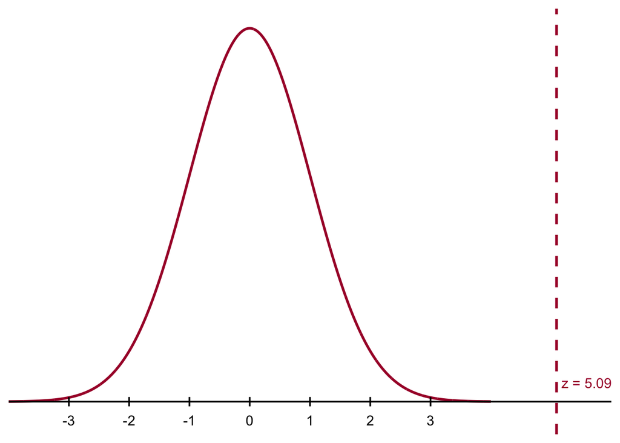

3. With a significance level of $\alpha = 0.05$, since the $p$-value is $\approx 0 < 0.05 = \alpha$, we reject the null hypothesis $H_0$ and conclude that there is sufficient evidence to suggest that the percentage of all Americans who believe that global warming is caused by human activities has increased from 2015 to 2017.

**TipExample 8.2.2.**

**Question**

According to census.gov, Duval County is about 30% African American. Suppose you are looking at jury pools for Duval County, each with 400 members in it. The null hypothesis is that the probability of an African American being selected into the jury pool is 30%.

1. How many African Americans would you expect on a jury pool of 400 people if the null hypothesis is true?
2. Suppose pool A contains 100 African American people out of 400, and pool B contains 130 African American people out of 400. Which will have a smaller $p$-value and why?

**Answer**

1. If the null hypothesis is true, we would expect 30% of 400 people to be African American. This can be calculated as follows:
   $$\text{Number of African Americans} = 0.30 \times 400 = 120.$$
2. To determine which pool will have a smaller $p$-value, we need to calculate the test statistic for each pool.  
   For pool A:
- Sample proportion: $\hat{p}_A = \frac{100}{400} = 0.25$.
- Standard error:
  $$\text{SE}_A = \sqrt{\frac{p_0(1 - p_0)}{n}} = \sqrt{\frac{0.30(1 - 0.30)}{400}} = \sqrt{\frac{0.21}{400}} = \sqrt{0.000525} \approx 0.0229.$$
- $z$-statistic:
  $$z_A = \frac{\hat{p}_A - p_0}{\text{SE}_A} = \frac{0.25 - 0.30}{0.0229} \approx \frac{-0.05}{0.0229} \approx -2.18.$$
  For pool B:
- Sample proportion: $\hat{p}_B = \frac{130}{400} = 0.325$.
- Standard error:
  $$\text{SE}_B = \sqrt{\frac{p_0(1 - p_0)}{n}} = \sqrt{\frac{0.30(1 - 0.30)}{400}} = \sqrt{\frac{0.21}{400}} = \sqrt{0.000525} \approx 0.0229.$$
- $z$-statistic:
  $$z_B = \frac{\hat{p}_B - p_0}{\text{SE}_B} = \frac{0.325 - 0.30}{0.0229} \approx \frac{0.025}{0.0229} \approx 1.09.$$
  Since $z_A$ is further away from 0 than $z_B$ (in absolute value), pool A will have a smaller $p$-value.

**TipExample 8.2.3.**

**Question**

A public health department is testing water samples for contamination by a harmful bacteria. They set up the following hypotheses:

- $H_0$: The water is safe (no harmful bacteria present).
- $H_a$: The water is contaminated (harmful bacteria present).

After running the test, the lab concludes that the water is safe and does not issue a warning. However, a few days later, people in the community become ill, and further testing reveals that the water was actually contaminated. Which type of error did the lab make in this scenario?

**Answer**

The lab made a **Type II Error**. They failed to reject the null hypothesis $H_0$ (the water is safe) when it was actually false (the water was contaminated).

**TipExample 8.2.4.**

**Question**

A city’s health department claims that 20% of adults in the city smoke cigarettes. A public health researcher believes that this percentage is lower and conducts a survey to test the claim.

1. What is the null hypothesis?
2. What is the alternative hypothesis?
3. If the researcher concludes that the percentage of adult smokers is lower than 20% when it is actually 20%, what type of error has been made?

**Answer**

1. The null hypothesis is $H_0: p = 0.20$.
2. The alternative hypothesis is $H_a: p < 0.20$.
3. The researcher has made a **Type I Error** by rejecting the null hypothesis $H_0$ when it is actually true.

## Section 8.3. Confidence Intervals and Hypothesis Tests

Recall that the significance level $\alpha$ in hypothesis testing is the maximum acceptable probability of making a Type I error. If we subtract the significance level $\alpha$ from 1, we get the **confidence level** of a confidence interval (from Chapter 7).

**ImportantConfidence Level and Significance Level**

If the significance level is $\alpha$, then the confidence level is $1 - \alpha$.

| Significance Level $\alpha$ | Confidence Level: $1 - \alpha$ | Alternative Hypothesis |
| --- | --- | --- |
| 10% | 90% | Two-Sided: $\neq$ |
| 5% | 95% | Two-Sided: $\neq$ |
| 1% | 99% | Two-Sided: $\neq$ |

**TipExample 8.3.1.**

**Question**

An infomercial advertisement claims that a Himalayan salt lamp can increase energy levels in people who use it. A medical researcher tests this claim with 326 people who claim to have low energy. He randomly assigned half of the group to use a genuine Himalayan salt lamp for four weeks and assigned the other half of the group to use a “look-alike” lamp for the same time period. After the four weeks, he surveys participants in both groups on their energy levels. After analyzing the data, he fails to reject the null hypothesis. Which of the following are valid interpretations of his findings? There may be more than one correct answer?

1. The Himalayan salt lamps are not effective at increasing energy levels.
2. There’s insufficient evidence that the Himalayan salt lamps are effective at increasing energy levels.
3. The Himalayan salt lamps had exactly the same effect as the look-alike lamps in increasing energy levels.
4. There were no statistically significant differences between the Himalayan salt lamps and the look-alike lamps at increasing energy levels.

**Answer**

The correct answers are b. and d.

**TipExample 8.3.2.**

**Question**

In 2015, the Pew Center estimated that 56% of Americans support the death penalty. In 2016, a Pew Center poll found that 49% support the death penalty. Suppose that the 2016 poll was conducted on a random sample of 1201 respondents. Do we have evidence that support of the death penalty has changed among Americans since 2015? Use the [webapp](https://ckaoxvii.github.io/population-proportion-hypothesis-test/) to help you answer the following questions.

1. Conduct a hypothesis test at the $\alpha = 0.05$ significance level.
2. Construct a 95% confidence interval for the true proportion of Americans who support the death penalty in 2016.
3. Do the results from the hypothesis test and the confidence interval agree? Explain.

**Answer**

1. First note that $p_0 = 0.56$, $\hat{p} = 0.49$, and $n = 1201$. The hypotheses are:
- $H_0: p = 0.56$
- $H_a: p \ne 0.56$  
  The $p$-value from the hypothesis is $< 0.00001 < 0.05 = \alpha$. Therefore, we reject the null hypothesis $H_0$ and conclude that there is sufficient evidence to suggest that support of the death penalty has changed among Americans since 2015.
2. The 95% confidence interval for the true proportion of Americans who support the death penalty in 2016 is approximately (0.460, 0.520).
3. The conclusion of our hypothesis test indicates that the proportion has changed since 2015. This is supported by the 95% confidence interval, which does not contain the hypothesized proportion of 0.56. Therefore, the results from the hypothesis test and the confidence interval agree.

**TipExample 8.3.3.**

**Question**

**Answer**

## Section 8.4. Hypothesis Tests for Two Proportions

The general procedure for conducting hypothesis tests for two proportions is similar to that for one proportion. We highlight the key differences here.

1. The null and alternative hypotheses now involve two proportions.

| **Hypothesis** | **Type** |
| --- | --- |
| $H_0: p_1 = p_2$ $H_a: p_1 \ne p_2$ | Two-Sided |
| $H_0: p_1 = p_2$ $H_a: p_1 < p_2$ | Left-Sided |
| $H_0: p_1 = p_2$ $H_a: p_1 > p_2$ | Right-Sided |

2. The test statistic for two proportions is given by
   $$z = \frac{\hat{p}_1 - \hat{p}_2}{\text{SE}},$$
   where
   $$\begin{align}
   \text{SE} &= \sqrt{\hat{p}(1 - \hat{p}) \left(\frac{1}{n_1} + \frac{1}{n_2}\right)},\\\
   n_1 &= \text{sample size in sample 1},\\\
   n_2 &= \text{sample size in sample 2},\\\
   \hat{p} &= \frac{\text{number of successes in sample 1} + \text{number of successes in sample 2}}{n_1 + n_2},\\\
   \hat{p}_1 &= \text{sample proportion in sample 1},\\\
   \hat{p}_2 &= \text{sample proportion in sample 2}.
   \end{align}$$
3. The conditions for the Central Limit Theorem must hold for both samples.

You will not be asked to calculate these by hand on the test.

- Large samples:
  - $n_1 \hat{p} \geqslant 10$ and $n_1 (1 - \hat{p}) \geqslant 10$
  - $n_2 \hat{p} \geqslant 10$ and $n_2 (1 - \hat{p}) \geqslant 10$
- Random samples: Samples are drawn randomly and independently from the populations of interest.
- Independent samples: The two samples are independent of each other.
- Independence within samples: The observations within each sample are independent of each other.

The rest of the hypothesis testing procedure (i.e., calculating the $p$-value, making a decision, and interpreting the results) is the same as that for one proportion.

## Section 8.4. Examples

**TipExample 1.**

**Question**

A student is interested in determining if there are gender differences on pet ownership. She collects data from a random sample of 75 men and 45 women. Of the 75 men, 50 reported they had at least one pet. Of the 45 women, 29 reported they had at least one pet. Assume the samples were random and independent. Use $\alpha = 0.05$.

1. Complete the following table.

|  | Men | Women | Total |
| --- | --- | --- | --- |
| Pets |  |  |  |
| No Pets |  |  |  |
| Total | 75 | 45 | 120 |

2. Write the null and alternative hypotheses.
3. Use the [webapp](https://ckaoxvii.github.io/two-population-proportion-hypothesis-test/) to perform the hypothesis test.
4. Plot the test statistic and shade the area representing the $p$-value.

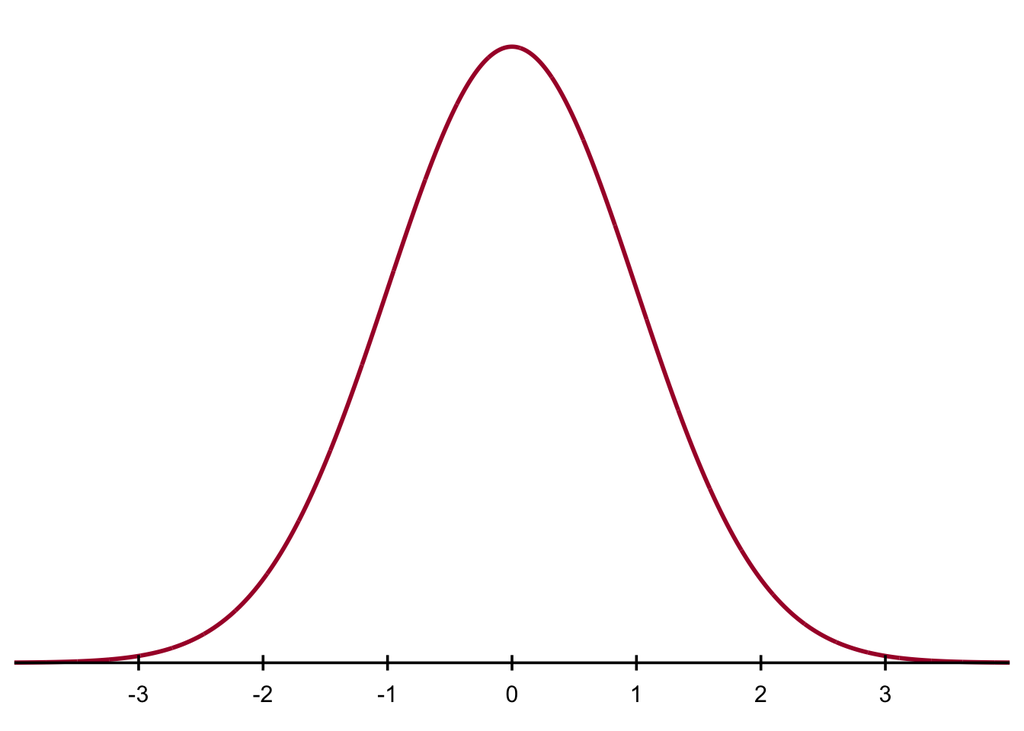

5. Interpret the results in the context of the problem.

**Answer**

1. The completed table is as follows:

|  | Men | Women | Total |
| --- | --- | --- | --- |
| Pets | 50 | 29 | 79 |
| No Pets | 25 | 16 | 41 |
| Total | 75 | 45 | 120 |

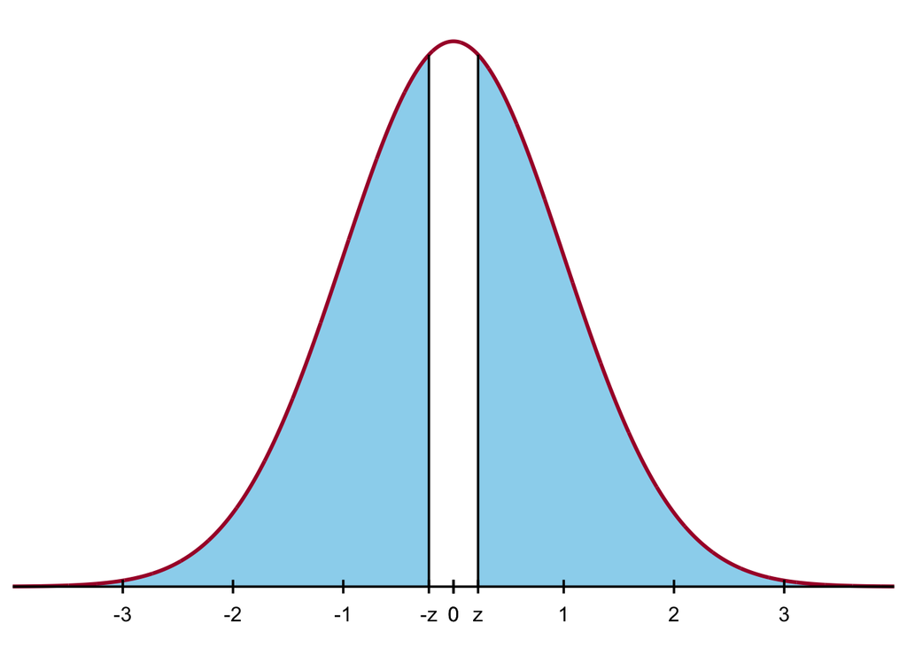

5. Since the $p$-value of 0.82374 is greater than the significance level of $\alpha = 0.05$, we fail to reject the null hypothesis $H_0$. This means that there is insufficient evidence to suggest a difference in pet ownership between men and women.

[figure not shown]